# DAKD2023_ex2_Faiza_Anan_Noor

## Please fill up the asked information!

Name: Faiza Anan Noor

Student number: 2306676

Mail: fanoor@utu.fi

```python
from google.colab import drive
drive.mount('/content/drive')
```

# Data Analysis and Knowledge Discovery: Exercise 2, Supervised learning

The previous exercise was about *data understanding* and *data preparation*, which formed the basis for the modeling phase of the data mining process. Many modeling techniques make assumptions about the data, so the exploration and preparation phases can't be ignored. Now, as we have checked the validity of data and familiarized ourselves with it, we can move on to the next stage of the Cross-Industry Standard Process for Data Mining (CRISP-DM), which is modeling.

The questions to be answered at this stage could include:

- What kind of model architecture best fits our data?
- How well does the model perform technically?
- Could we improve its performance?
- How do we evaluate the model's performance?

*Machine learning* is a subfield of artificial intelligence that provides automatic, objective and data-driven techniques for modeling the data. Its two main branches are *supervised learning* and *unsupervised learning*, and in this exercise, we are going to use the former, supervised learning, for classification and regression tasks.

For classification, data remains the same as in the previous exercise, but I've already cleaned it up for you. Some data pre-processing steps are still required to ensure that it's in an appropriate format so that models can learn from it. Even though we are not conducting any major data exploration nor data preparation this time, *you should **never** forget it in your future data analyses*.

**General guidance for exercises**

- Answer **all** questions below, even if you can't get your script to fully work.
- Write clear and easily readable code, and include explanations what your code does.
- Make informative illustrations: include labels for x and y axes, legends and captions for your plots.
- You can add more code and markup cells, as long as the flow of the notebook stays readable and logical.
- **A complete submission includes a working notebook**, so it's highly recommended to run "Restart & Run all" before the final save. Remember to submit BOTH versions of the exercise (ipynb AND html/pdf).
- Grading: *Fail*/*Pass*/*Pass with honors* (+1)
  - Passing requires that **the parts 1-5** are completed.
  - +1 bonus point (grading *Pass with honors*) requires a **completely** correct solution and also thorough analysis.
- If you encounter problems, Google first. Always give the credit where it belongs so please **cite your sources, whether you're referencing text or code**. You will learn so much more when you have to research and summarize information in your own words. If you can't find an answer to the problem, don't hesitate to ask in the Moodle discussion or directly via email (tuhlei@utu.fi).
- Note! Don't leave it to the last moment! No feedback service during weekends.
- **We do not encourage the use of ChatGPT or similar models**, but if you choose to do so, always be critical of the outputs and try to comprehend them before any use. Also, make a brief description how you utilized the model (what was your input and how did you benefit from the output).

The guided exercise session is held on the 28th of November at 14:15-16:00, at TSE Elovena-Sali.

**The deadline is the 30th of November at 23:59**. Late submissions will not be accepted unless there is a valid excuse for an extension which should be asked **before** the original deadline.

### Gather all packages needed for this notebook here:

You can use other packages as well, but this excercise can be completed with those below.

```python
import numpy as np
import pandas as pd

# Visualization packages - matplotlib and seaborn
# Remember that pandas is also handy and capable when it comes to plotting!
import seaborn as sns
import matplotlib.pyplot as plt

# Machine learning package - scikit-learn
from sklearn import metrics
from sklearn.preprocessing import StandardScaler
from sklearn.model_selection import train_test_split, cross_val_score, LeaveOneOut, GridSearchCV
from sklearn.neighbors import KNeighborsClassifier, KNeighborsRegressor
from sklearn.linear_model import Ridge, LinearRegression

# Show the plots inline in the notebook
%matplotlib inline

##########################################################
from sklearn.metrics import accuracy_score, roc_curve, roc_auc_score, classification_report, confusion_matrix, ConfusionMatrixDisplay, mean_absolute_error


# Show the plots inline in the notebook
%matplotlib inline
```

## 1. Classification using k-nearest neighbors

We start exploring the world of data modeling by using the K-Nearest Neightbors (k-NN) algorithm. The k-NN algorithm is one of the classic supervised machine learning algorithms which assumes that similar points are close to each other.

In our case, we'll use the k-NN algorithm to *predict the presence of cardiovascular disease* (CVD) using all the other variables as features in the given data set. I.e. the target variable that we are interested in is `cardio`.

But first, we need data for the task. The code for loading the data into the environment is provided for you. The code should work but make sure that you have the CSV file of the data in the same directory where you have this notebook file.

**Exercise 1 A)**

Take a random sample of 1500 rows from the dataframe using your student id as a seed. Print the first 15 rows to check that everything is ok with the dataframe.

*Note: as mentioned, the data remains the same, but cholesterol has been one-hot-encoded for you already. There's also a new variable, gluc (about glucose levels), which is one-hot-encoded for you. It has similar values as cholesterol originally had [normal, at risk, elevated].*

```python
### Loading code provided
# ------------------------------------------------------
# The data file should be at the same location than the
# exercise file to make sure the following lines work!
# Otherwise, fix the path.
# ------------------------------------------------------

# This is the path for the data in CSV form
data_path = '/content/drive/MyDrive/ex2_cardio_data.csv'

# Reading the CSV file into the variable called cardio_data
cardio_data = pd.read_csv(data_path)
```

```python
### Code - Resample and print 15 rows. We store it into a variable called "sampled_cardio_df"
sampled_cardio_df = cardio_data.sample(n=1500, random_state=123)

# Printing the first 15 rows of the sampled DataFrame
print(sampled_cardio_df.head(15))
```

```
      age  gender  height  weight  ap_hi  ap_lo  smoke  alco  active  cardio  \
1201   56       2     171    89.0    140     90      1     0       1       0
1084   51       2     166    62.0    150     80      0     0       0       0
2060   52       1     166    70.0    120     80      0     0       1       0
248    51       1     172    82.0    120     80      0     0       1       0
5603   61       1     156    58.0    140     80      0     0       1       1
5992   44       1     178    76.0    140     80      0     0       1       1
2891   61       1     154    97.0    140     80      0     0       0       0
2102   45       1     166    63.0    115     70      0     0       1       0
989    53       1     160    59.0    100     70      1     0       1       0
5624   53       1     156    62.0    120     80      0     1       1       1
1314   44       2     170    71.0    120     80      0     0       1       0
1435   56       1     157    71.0    120     80      0     0       1       0
4175   45       1     150    67.0     90     70      0     0       1       0
2524   41       1     170    75.0    120     80      0     0       1       0
```

[output cut: 35 more lines]

We have the data so now, let's put it to use.

To teach the k-NN algorithm (or any other machine learning algorithm) to recognize patterns, we need training data. However, to assess how well a model has learned these patterns, we require test data which is new and unseen by the trained model. It's important to note that the test set is not revealed to the model until after the training is complete.

So, to *estimate the performance of a model*, we may use a basic train-test split. The term "split" is there because we literally split the data into two sets.

**Exercise 1 B)**

Collect the features as an array named `features`, and the target variable as an array named `labels`. Create training and test data by randomly splitting the data into training (80%) and test (20%) sets.

- Do you need stratification for our dataset? Explain your decision.

```python
sampled_cardio_df.dtypes
```

```
age                       int64
gender                    int64
height                    int64
weight                  float64
ap_hi                     int64
ap_lo                     int64
smoke                     int64
alco                      int64
active                    int64
cardio                    int64
cholesterol_normal        int64
cholesterol_elevated      int64
cholesterol_high          int64
gluc_normal               int64
gluc_elevated             int64
gluc_high                 int64
dtype: object
```

After performing one-hot encoding, the categorical variables are transformed into numerical format.

One-hot encoding is a technique used to convert categorical variables into a binary matrix where each category becomes a column, and for each observation, only one column will have a value of 1 while the rest will be 0s. This transformation allows machine learning algorithms to interpret categorical data effectively. Each original categorical value becomes a binary column in the dataset. When these are presented in a numerical format, machine learning models can handle them appropriately for training and prediction.

Then we separate features and labels.

```python
# Separating the features of cardio
cardio_features=sampled_cardio_df.drop(columns=["cardio"])
cardio_labels=sampled_cardio_df["cardio"]
cardio_labels
```

```
1201    0
1084    0
2060    0
248     0
5603    1
       ..
990     0
134     0
3483    0
2688    0
1069    0
Name: cardio, Length: 1500, dtype: int64
```

Stratification is particularly useful when dealing with imbalanced datasets, where the distribution of classes in the target variable is uneven. It ensures that the distribution of classes in both the training and test sets closely matches the original dataset.

If our dataset has a balanced distribution of classes, stratification might not be strictly necessary, but it can still be beneficial in preventing any potential bias in the splitting process.

To decide whether stratification is needed for our dataset, it's essential to examine the distribution of classes in your target variable. If there's a relatively equal representation of different classes, we might opt to split the data without stratification. For our case, there was unbalanced distribution of classes and hence stratification is needed so that the distribution of classes in train and test sets matches the original one.

Then we separate use train_test_split() function to separate cardio_features, cardio_labels into "**cardio_X_train, cardio_X_test, cardio_y_train, cardio_y_test**"

```python
cardio_X_train, cardio_X_test, cardio_y_train, cardio_y_test = train_test_split(cardio_features, cardio_labels, test_size=0.20, random_state=42, stratify=cardio_labels
                                                    )
cardio_X_train.head(4)
```

|  | age | gender | height | weight | ap_hi | ap_lo | smoke | alco | active | cholesterol_normal | cholesterol_elevated | cholesterol_high | gluc_normal | gluc_elevated | gluc_high |
| --- | --- | --- | --- | --- | --- | --- | --- | --- | --- | --- | --- | --- | --- | --- | --- |
| 112 | 64 | 1 | 150 | 67.0 | 154 | 92 | 0 | 0 | 0 | 1 | 0 | 0 | 1 | 0 | 0 |
| 5583 | 46 | 1 | 165 | 70.0 | 130 | 80 | 0 | 0 | 1 | 1 | 0 | 0 | 1 | 0 | 0 |
| 2440 | 51 | 1 | 170 | 82.0 | 130 | 80 | 0 | 0 | 1 | 0 | 1 | 0 | 1 | 0 | 0 |
| 704 | 39 | 1 | 156 | 78.0 | 90 | 70 | 0 | 0 | 0 | 1 | 0 | 0 | 1 | 0 | 0 |

```python
print("Count for Total Labels: \n",sampled_cardio_df.cardio.value_counts(), end= '\n')
```

```
Count for Total Labels:
 0    1054
1     446
Name: cardio, dtype: int64
```

```python
print("Count for test labels: \n",cardio_y_test.value_counts(),end= '\n')
print("Count for training Labels: \n",cardio_y_train.value_counts(), end='\n')
```

```
Count for test labels:
 0    211
1     89
Name: cardio, dtype: int64
Count for training Labels:
 0    843
1    357
Name: cardio, dtype: int64
```

Using scikit-learn's train_test_split, this code snippet guarantees that the splitting is stratified using stratify on the labels. Test_size=0.2 indicates a 20% test split. The reason we should employ startification is that it will guarantee that the labels in the training and testing datasets we obtain after splitting include the same percentage as in the original dataset.

Here, the percentage of labels in the train and test set is the same as the original for stratification.

**Exercise 1 C)**

Standardize the numerical features: Note that you should now have two separate features that you've divided all the features into.

- Describe how the k-NN model would make predictions about whether or not a patient has a CVD when the features are not standardized, and explain the reasons behind.

*Note: Some good information about preprocessing and how to use it for train and test data can be found https://scikit-learn.org/stable/modules/preprocessing.html*.

Then we standardized the numeric features using Standard Scaler. Our numeric features are :

**age, height, weight, ap_hi, ap_lo**

```python
#numerical_features=features.select_dtypes(include=['float64'])

numeric_features = ['age','height','weight','ap_hi','ap_lo']
scaler = StandardScaler()
cardio_features[['age','height','weight','ap_hi','ap_lo']]=scaler.fit_transform(cardio_features[['age','height','weight','ap_hi','ap_lo']])
cardio_features.head(3)
```

|  | age | gender | height | weight | ap_hi | ap_lo | smoke | alco | active | cholesterol_normal | cholesterol_elevated | cholesterol_high | gluc_normal | gluc_elevated | gluc_high |
| --- | --- | --- | --- | --- | --- | --- | --- | --- | --- | --- | --- | --- | --- | --- | --- |
| 1201 | 0.583784 | 2 | 0.776227 | 1.148632 | 0.016536 | -0.010006 | 1 | 0 | 1 | 1 | 0 | 0 | 1 | 0 | 0 |
| 1084 | -0.153938 | 2 | 0.182176 | -0.850070 | 0.044342 | -0.111489 | 0 | 0 | 0 | 1 | 0 | 0 | 1 | 0 | 0 |
| 2060 | -0.006394 | 1 | 0.182176 | -0.257862 | -0.039077 | -0.111489 | 0 | 0 | 1 | 1 | 0 | 0 | 1 | 0 | 0 |

**Concept of standardization:** Standardizing characteristics ensure that each feature contributes equally to distance computations (for example, by scaling them to have a mean of 0 and a standard deviation of 1). It assists in preventing any single trait from dominating the decision-making process.

**Impact of not standardizing:** When k-NN features lack standardization, higher scale or magnitude characteristics may have a stronger effect on distance calculations, whereas features with lower scales may be less influenced by identification of closest neighbors. In our example, if the data is not normalized, greater values of a variable, say age, might greatly skew the findings, especially when using the K-NN model, because the basic principle revolves around utilizing closeness/proximity of data points to create classifications or predictions about the grouping of an individual data point.

When making predictions, the k-NN model could determine a characteristic's importance incorrectly in the absence of standardization. Forecasts may become skewed as a result, favoring some traits over others based merely on larger scales, even when these traits have less significance for the prediction of cardiovascular disease (CVD).

It's time for us to train the model!

**Exercise 1 D)**

Train a k-NN model with $k=3$. Print out the confusion matrix and use it to compute the accuracy, the precision and the recall.

- What does each cell in the confusion matrix represents in the context of our dataset?
- How does the model perform with the different classes? Where do you think the differences come from? Interpret the performance metrics you just computed.
- With our dataset, why should you be a little more cautious when interpreting the accuracy?

```python
### Code - the kNN classifier
# Here we have passed in knn_neighbors as 3.
knn_clf = KNeighborsClassifier(n_neighbors=3)
knn_clf.fit(cardio_X_train, cardio_y_train)
results_clf_knn=knn_clf.predict(cardio_X_test)
```

We have used each index of the Confusion Matrix to compute the accuracy, precision, recall.

```
Precision (From Confusion Matrix): 0.5287356321839081
Recall (From Confusion Matrix): 0.5168539325842697
Accuracy (From Confusion Matrix): 0.72
```

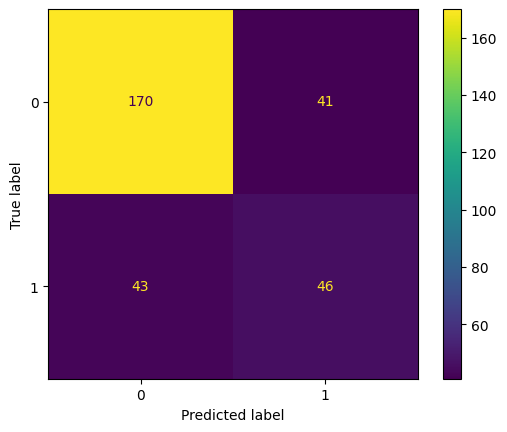

```python
### Code - Printing out confusion matrix. To do this we pass in actual values and predicted values by the KNN.
cm = confusion_matrix(cardio_y_test, results_clf_knn)
disp = ConfusionMatrixDisplay(confusion_matrix=cm)


#From the Confusion Matrix, 4 indices refer to different things. The position (0,0) refer to true negative, (0,1) refer to false positive,
# (1,0) refer to false negative, (1,1) refer to true positive)

tp = cm[1, 1]
fp = cm[0, 1]
fn = cm[1, 0]
tn = cm[0,0]

# Then we use the values from the confusion matrix to compute accuracy, precision and recall
precision = tp / (tp + fp) if (tp + fp) != 0 else 0
recall = tp / (tp + fn) if (tp + fn) != 0 else 0
accuracy=(tp+tn) / (tp + fp+tn+fn) if (tp + fp+tn+fn) != 0 else 0

# Print precision and recall
print("Precision (From Confusion Matrix):", precision)
print("Recall (From Confusion Matrix):", recall)
print("Accuracy (From Confusion Matrix):", accuracy)

disp.plot()
plt.show()
```

We also examine the classification report by passing in main and predicted values by KNN model.

```python
print(classification_report(cardio_y_test, results_clf_knn,))
```

```
              precision    recall  f1-score   support

           0       0.80      0.81      0.80       211
           1       0.53      0.52      0.52        89

    accuracy                           0.72       300
   macro avg       0.66      0.66      0.66       300
weighted avg       0.72      0.72      0.72       300
```

\

### **Confusion Matrix Interpretation: Each cell in the confusion matrix represents different aspects in the context of your dataset:**

**True Positives (TP):** Instances where the model correctly predicts the positive class (CVD present). For our case, the TP is 46.

**True Negatives (TN):** Instances where the model correctly predicts the negative class (CVD not present). For our case, the TN is 170.

**False Positives (FP):** Instances where the model incorrectly predicts the positive class (predicts CVD present when it's not). For our case, the FP is 41.

**False Negatives (FN):** Instances where the model incorrectly predicts the negative class (predicts CVD not present when it is). For our case, the FN is 43.

### **How the model perform with the different classes and the differences come from. Interpret the performance metrics you just computed:**

The class imbalance (one class having much less samples), the inner complexity or separability of the classes, or problems with feature representation or selection might all be contributing causes to the performance discrepancies across the classes.

By analyzing these metrics, one may determine how effectively the model is working and where it can benefit from adjustments, such as adjusting the model's parameters, feature engineering approaches, or class distribution.

**Interpreting Performance Metrics:**

Accuracy measures the total number of accurate forecasts. However, accuracy by itself could not give a whole view of the model's performance in unbalanced datasets (e.g., where one class considerably dominates the other). Because the model tends to forecast the majority class more frequently while still doing badly on the minority class, accuracy may be high in situations when there is a significant class imbalance. Precision signifies the accuracy of positive predictions. Recall, also referred to as sensitivity, is the percentage of real positives that were accurately recognized. A high accuracy indicates that the model predicts both classes with good overall performance. Reduced accuracy might indicate a mistake in one or both classes.

Since in our case, the support values(number of samples) indicate 211 samples for value 0 and 89 values for value 1 for our sampled test dataset, it can be concluded that there is a huge class imbalance. The results precision, recall also vary accordingly for different classes even though the accuracy came to be 72%. But the precision, recall for class 0 are 80%, 81% and for class 1 are 53% and 52%. And when they are averaged they become 66% and 72%. F1 score is a useful metric to use to strike a balance between Precision and Recall.

When a model predicts a class with high accuracy, it typically gets it right. A large number of false positives might indicate low accuracy. A high recall score means that the model can accurately identify the majority of examples within a class. Missing a lot of those class instances might be the result of low recall.

### **With our dataset, the reason to be a little more cautious when interpreting the accuracy:**

It is important to exercise caution when assessing accuracy in unbalanced datasets since high accuracy does not always imply a strong performance in identifying. While accuracy is a commonly used metric, with imbalanced datasets (where one class dominates), a high accuracy score might be misleading. For example, if the model predicts the majority class most of the time, it could achieve high accuracy despite poor performance on the minority class.

Therefore, precision and recall should be taken into account in addition to accuracy when working with datasets that include unbalanced classes, such as those used to predict CVD. Recall demonstrates the model's capacity to record every positive occurrence, whereas precision reveals the model's ability to prevent false positives.

Understanding these metrics helps in assessing how well the model performs with different classes and aids in interpreting its effectiveness in predicting CVD presence.

You randomly divided the data into two sets, one for training the k-NN model and the other for evaluating its performance. However, randomness is not the thing we really need, and in fact, it's not something we even desire. Instead, what we do want is to keep track of each step we're making and exporing. This said, the *reproducibility* of the results is extremely important in research. To achieve this, we can utilize a random seed, with which we can re-run the codes and get the exact same results than before.

For example, we can use a fixed seed when we're shuffling the data before splitting it into training and test sets. This ensures that when we're re-runing the code, we obtain exactly the same partitions of the data in each split.

**Exercise 1 E)**

Initialize 1000 random seeds and continue with the k-NN model ($k=3$): Perform 1000 different train-test splits using these seeds and store the accuracies from each split. Plot the accuracies in a histogram, and discuss your results.

*Tip: You can add the accuracy from the previous exercise in the plot by drawing a vertical line with the function `matplotlib.axes.Axes.axvline(<accuracy>)` if you want!*

```python
### Code - Initialization of the 1000 fixed seeds

# Here, we define the number of splits as num_splits
num_splits = 1000

# Then we initialize 1000 random seeds to be used as seed later.
random_seeds = np.random.randint(1, 10000, size=num_splits)
```

We initialize 1000 random seeds and continue with the k-NN model (k=3) and perform 1000 different train-test splits using these seeds and store the accuracies from each split in acc_seed array, and also store seed values in seed_val array and plotted accuracies in histograms.

```python
### Code - Using 1000 different train-test-splits and using k=3 for knn models with different subsets each time using the seeds
acc_seed=[]
seed_val=[]
for seed in random_seeds:
    cardio_X_train2, cardio_X_test2, cardio_y_train2, cardio_y_test2 = train_test_split(cardio_features, cardio_labels, test_size=0.2, random_state=seed)

    # Creating k-NN model with k=3
    knn = KNeighborsClassifier(n_neighbors=3)
    knn.fit(cardio_X_train2, cardio_y_train2)

    # Calculating accuracy for each random seed and storing results for accuracy and seed value in two variables acc_seed and seed_val
    accuracy2 = knn.score(cardio_X_test2, cardio_y_test2)
    acc_seed.append(accuracy2)
    seed_val.append(seed)
```

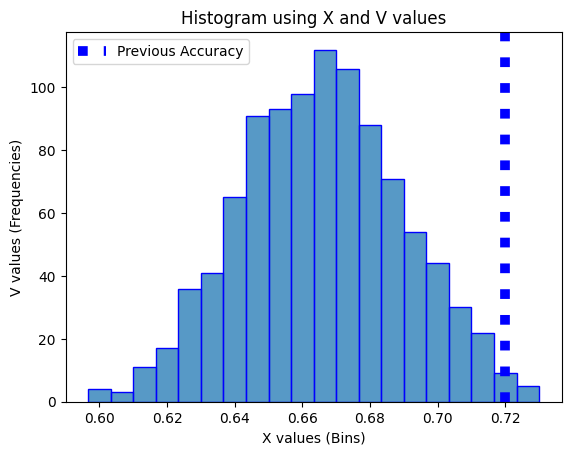

```
Previous accuracy value is:  0.72
```

```python
sns.histplot(acc_seed, edgecolor='blue')
plt.xlabel('X values (Bins)')
plt.ylabel('V values (Frequencies)')
plt.title('Histogram using X and V values')
plt.axvline(x=accuracy, linewidth=7, color='b', linestyle=':', label='Previous Accuracy')
plt.legend()
plt.show()

print("Previous accuracy value is: ", accuracy)
```

\

One really common evaluation metric is the area under the receiver operating characteristic (AUROC, AUC or AUC-ROC). It provides a measure of a model's ability to distinguish between classes, especially in binary classification tasks between the *positive class* and the *negative class*. (There sure are multiclass and multilabel cases too, but they are out of scope here.)

In our case, individuals who have a CVD form the positive class. As the name of the measure suggests, it combines two keys aspects to interpret a model's performance: ROC curves are about the trade-off between the true positive rate and the false positive rate, the former representing the model's ability to correctly identify individuals with a CVD (true positives) and the latter measuring the model's tendency to incorrectly classify individuals without a CVD as if they have the disease (false positives). Thus, the area beneath the curve is simply the AUROC, a single numerical value, that summarizes the overall performance.

**Exercise 1 F)**

Evaluate the performance of the trained k-NN model by computing the AUROC and plotting the related curve. Draw also the line for random guesses.

- How well does the k-NN model perform in distinguishing between healthy individuals and those with a CVD?

*Tip: You should not use the predicted labels in this exercise.*

```
The ROC AUC Score:  0.7042174769689546
```

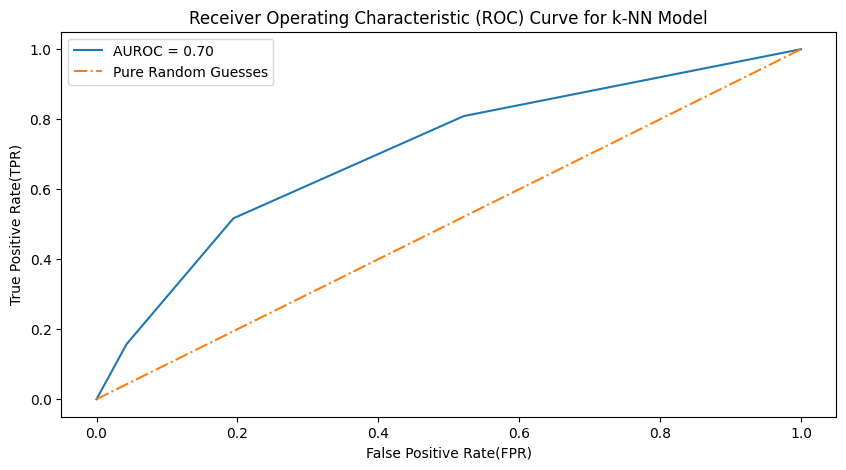

```python
### Code - ROC curve and AUROC

predicted_probabilities = knn_clf.predict_proba(cardio_X_test)[:,1]
print("The ROC AUC Score: ",roc_auc_score(cardio_y_test, predicted_probabilities))

fpr, tpr, thresholds = roc_curve(cardio_y_test, predicted_probabilities)
auroc = roc_auc_score(cardio_y_test, predicted_probabilities)

# Plotting the ROC curve
plt.figure(figsize=(10, 5))
plt.plot(fpr, tpr, label=f'AUROC = {auroc:.2f}')
plt.plot([0, 1], [0, 1], linestyle='-.', label='Pure Random Guesses')

plt.xlabel('False Positive Rate(FPR)')
plt.ylabel('True Positive Rate(TPR)')
plt.title('Receiver Operating Characteristic (ROC) Curve for k-NN Model')
plt.legend()
plt.show()
```

\

A model's AUC ROC value indicates how well it can differentiate across classes. With an AUC of 0.5, our model is unable to differentiate between different classes (random guess). Greater performance is indicated by a curve that approaches the upper left corner. The steeper the curve, the more precisely it can discern between the classes. Our model's AUC of 0.70 suggests that it performs rather well.

## 2. Classification accuracy using leave-one-out cross-validation

While the train-test split may provide us with an unbiased estimate of the performance, we only evaluate the model once. Especially when dealing with small datasets, a test set itself will be very small. How can we be sure that the evaluation is accurate with this small test set and not just a good (or bad) luck? And what if we'd like to compare two models and the other seems to be better -- how can we be sure that it's not just a coincidence?

Well, there's a great help available and it's called cross-validation. With its help, we can split the dataset into multiple different training and test sets, which allows us to evaluate models across various data partitions. This time, we'll take a closer look at the leave-one-out cross-validation.

**Exercise 2**

Let's keep the focus on detecting the CVD, so once again we utilize the k-NN model (with $k=3$) to predict the precense of the disease. Now, apply leave-one-out cross-validation to assess whether the k-NN model is suitable for addressing the problem. You may use the entire dataset on this task.

- What can you say about the accuracy compared to the previous task?
- What do you think: Does the k-NN model work for the problem in hand? Explain your answer.

*Tip: This sure can be done manually, but `cross_val_score` is quite a handy function too.*

```python
cardio_features.shape[0]
```

```
1500
```

cross_val_score function has been used to perform leave-one-out cross validation

```python
### Code - Leave-one-out cross-validation

# Making a k-NN classifier with k equal to 3.
knn_clf = KNeighborsClassifier(n_neighbors=3)

# Executing leave-one-out cross-validation
# Setting the 'cv' parameter to the number of samples for Leave out cross validation
# Setting the'scoring' parameter to 'accuracy' to extract accuracy scores and calculate mean accuracy
mean_accuracy_loocv = np.mean(cross_val_score(knn_clf, cardio_features, cardio_labels, cv=LeaveOneOut(), scoring='accuracy'))


# Printing the average accuracy from Leave Out One CV
print("Mean Accuracy with Leave-One-Out CV:", mean_accuracy_loocv)
```

```
Mean Accuracy with Leave-One-Out CV: 0.666
```

\

**Accuracy compared to the previous task:**

The accuracy previously was 72% and now it is 66% using the leave out out cross validation method.

**Reason:** Cross-validation continuously separates the dataset into training and validation sets to assess a model's performance. The final accuracy may be somewhat less than the test accuracy due to these split changes, potential fluctuations in the data distributions, and the tuning of hyperparameters based on the cross-validation folds. Because cross-validation evaluates the model using the training data, it may understate the real test performance even if it provides a more complete review over numerous rounds. Perhaps a more accurate indicator of the model's capacity for generalization is the accuracy obtained via Cross Validation It may be an indicator of the model's sensitivity to new data points or possible problems with generalization if the accuracy from Cross Validation differs noticeably from earlier evaluations.

**Applicability for k-NN model for the problem in hand:**

The interaction of several variables within the dataset and the particulars of the issue determine whether k-NN is appropriate for CVD detection. The k-NN model's predictive power for cardiovascular disease (CVD) detection depends on its reliable and stable performance in assessments such as cross-validation and testing on unobserved data. k-NN can be deemed appropriate for the task if it continuously exhibits good accuracy, precision, and recall while taking dataset features and algorithmic restrictions into consideration. However, other models could be better suitable for accurate CVD diagnosis if it has trouble generalizing or if restrictions seriously affect its performance.

When the underlying relationships in the data are founded on local similarities or clusters, k-NN performs admirably. k-NN may successfully find related cases for classification if the CVD data shows distinct local patterns or clusters, as in our example. k-NN can utilize these correlations to provide reliable predictions if the dataset has distinguishable patterns and traits that separate CVD from non-CVD instances, such as our example. But elements that are too loud or unnecessary might make it less effective.

## 3. Model selection with leave-one-out cross-validation

So far, we've trained one model at a time and I've given the value of k for you. Accuracy is what it is (no spoilers here), but could we still do a little better? Let's explore that possibility through a process known as hyperparameter tuning. The cross-validation is especially important tool for this task. Note here, that model selection and model evaluation (or assessment) are two different things: We use model selection to estimate the performance of various models to identify the model which is most likely to provide the "best" predictive performance for the task. And when we have found this most suitable model, we *assess* its perfomance and generalisation power on unseen data.

This time, we're going to train multiple models, let's say 30, and our goal is to select the best K-Nearest Neighbors model from this set. Most models come with various hyperparameters that require careful selection, and the k-NN model is no exception. Although we're talking about the number of neighbors here, it's important to note that k-NN also has several other hyperparameters. However, for the sake of simplicity, this time we'll focus solely on fine-tuning the number of nearest neighbors, that is, the value of k.

Let's focus on the model selection part here for the sake of comprehending the cross-validation itself. We'll get later on the whole pipeline, which also includes model assessment.

**Exercise 3**

Find the optimal k value from a set of $k=1...30$ using leave-one-out cross-validation. Plot the accuracies vs. the k values. Again, you may use the entire dataset.

- Which value of k produces the best accuracy when using leave-one-out cross-validation? Compare the result to the previous model with $k=3$.
- If the number of k is still increased, what is the limit that the accuracy approaches? Why?
- Discuss the impact of choosing a very small or very large number of neighbors on the k-NN model's ability to distinguish between the healthy individuals and the ones with CVD.

```python
### Code -

# Here, we used GridSearchCv to find out the best parameter/n_neighbour from k = 1 ... 30 .
# We have used the whole dataset.

grid_search_cv = GridSearchCV(KNeighborsClassifier(), {'n_neighbors': list(range(1,31))}, cv=LeaveOneOut())
grid_search_fit = grid_search_cv.fit(cardio_features, cardio_labels)
print("The best value of k according to Grid Search CV is ",grid_search_fit.best_params_)
```

```
The best value of k according to Grid Search CV is  {'n_neighbors': 29}
```

```python
# Then we stored the test results for different parameters/ n_neighbours
grid_res = pd.DataFrame(grid_search_fit.cv_results_)
grid_res[['param_n_neighbors','mean_test_score']].head(4)
```

|  | param_n_neighbors | mean_test_score |
| --- | --- | --- |
| 0 | 1 | 0.629333 |
| 1 | 2 | 0.697333 |
| 2 | 3 | 0.666000 |
| 3 | 4 | 0.696667 |

```python
### Code - Select best model and fit with the whole model.

best_knn = KNeighborsClassifier(n_neighbors=grid_search_fit.best_params_["n_neighbors"])
best_knn.fit(cardio_features, cardio_labels)
#best_knn.score(cardio_features, cardio_labels)
```

```
KNeighborsClassifier(n_neighbors=29)
```

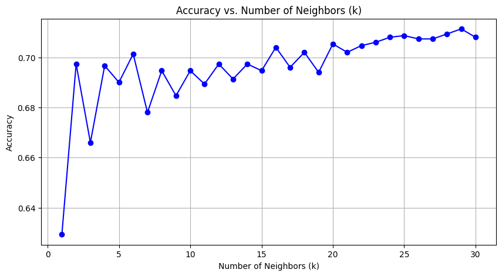

```python
### Code - Plot the accuracies vs. the values for k
# Plotting accuracies vs. k values

plt.figure(figsize=(10, 5))
plt.plot(grid_res["param_n_neighbors"], grid_res["mean_test_score"], marker='o', color='b')
plt.title('Accuracy vs. Number of Neighbors (k)')
plt.ylabel('Accuracy')
plt.grid(True)
plt.xlabel('Number of Neighbors (k)')

plt.show()
```

Then we increased k value even further and saw that the accuracy is stuck at the point where k = 29. That still remains the best k value.

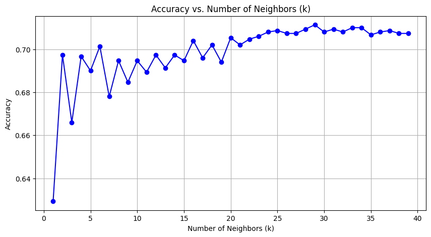

```python
# Here, we create the
grid_search_cv_extended = GridSearchCV(KNeighborsClassifier(), {'n_neighbors': list(range(1,40))}, cv=LeaveOneOut())
grid_search_fit_extended = grid_search_cv_extended.fit(cardio_features, cardio_labels)

best_knn_extended = KNeighborsClassifier(n_neighbors=grid_search_fit_extended.best_params_["n_neighbors"])
best_knn_extended.fit(cardio_features, cardio_labels)
plt.figure(figsize=(10, 5))


grid_res_extended = pd.DataFrame(grid_search_fit_extended.cv_results_)
grid_res_extended[['param_n_neighbors','mean_test_score']].head(4)
plt.plot(grid_res_extended["param_n_neighbors"], grid_res_extended["mean_test_score"], marker='o', color='b')
plt.title('Accuracy vs. Number of Neighbors (k)')
plt.ylabel('Accuracy')
plt.grid(True)
plt.xlabel('Number of Neighbors (k)')

plt.show()
```

```python
print("The best value of k according to Grid Search CV is ",grid_search_fit_extended.best_params_)
```

```
The best value of k according to Grid Search CV is  {'n_neighbors': 29}
```

\

For our case, even if the number of k values are increased, the accuracy increases upto 29. Accuracy tends to stop at a certain point. This may be the consequence of oversmoothing, in which the model becomes less sensitive to small-scale fluctuations in the data by employing an excessive number of neighbors.

### **Effect of Big/Small K on KNN:**

- **Little k values (like 1 or 3)**: They might be noisy and have an overfitting tendency.
- **Large k:** It has a propensity to oversmooth the decision border, which might cause underfitting.

To discern between people in good health and those suffering from CVD:

- **Small k:** May be impacted by noise or outliers, but may be able to catch more subtle variations between people suffering from CVD and not. Less neighbors allows for more complicated decision boundaries, which may be able to capture minute differences in the dataset. But because the model tends to memorize the training data, which increases variance, it may not generalize well to new or unknown occurrences.
- **Large k**: May work well for generalization, but it may also mask significant local differences, possibly leaving out crucial differences. Since more neighbors average out bigger k values, they are typically more resistant to isolated noisy data points. However, greater k values may overlook significant local information, particularly in areas where class changes often.

To successfully discriminate between healthy and CVD patients, the KNN model must strike a balance between overfitting and underfitting by choosing an ideal k.

## 4. Training and testing on the same dataset

*Note that this should never be done outside of this exercise! You have been warned.*

Oh, but what if we just trained a model using the *entire* dataset? Wouldn't we like to use as much data as possible to discover the underlying patterns in the data so why not to use all of it?

**Exercise 4**

This is quite straightforward: Train 30 k-NN models ($k = 1...30$ ) using the whole dataset and evaluate the trained models using, again, the whole dataset. Create a plot that displays the accuracies against the corresponding k values. Include the accuracy values from the previous task in the same figure.

- What's the optimal value for k now and why's that? How would you interpret the reliability of the predictions?
- Explain why you should never use the same dataset for training and testing.

We train 30 KNN models with k =1 to 30 and store the accuracy for all of them after training and testing on the whole dataset. That is we used cardio_features(containing all features) and cardio_labels(containing all labels) and evaluate accuracy using these exact sets too. We also extract the max value found after testing in this manner.

```python
### Code - Train with whole data

acc_knn_clf=[]
k_values_clf = list(range(1, 31))
for k in k_values_clf:
    knn = KNeighborsClassifier(n_neighbors=k)
    knn.fit(cardio_features, cardio_labels)
    acc_knn = accuracy_score(knn.predict(cardio_features), cardio_labels)
    acc_knn_clf.append(acc_knn)
```

Then we plotted the accuracies against the k values.

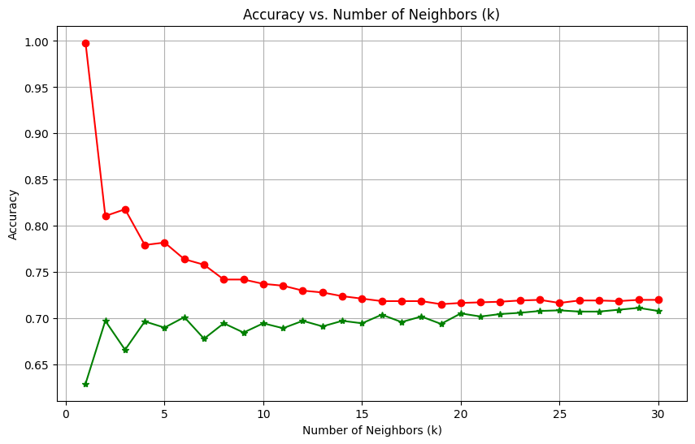

```python
### Code - Plot results
plt.figure(figsize=(10, 6))

plt.plot(grid_res["param_n_neighbors"], grid_res["mean_test_score"], marker='*', color='g')
plt.plot(k_values_clf, acc_knn_clf, marker='o', color='r')
plt.ylabel('Accuracy')
plt.title('Accuracy vs. Number of Neighbors (k)')

plt.grid(True)
plt.xlabel('Number of Neighbors (k)')

plt.show()
```

```python
accs=grid_res["mean_test_score"].tolist()
largest_acc = max(accs)
largest_k=accs.index(largest_acc)
print("Optimal value of k: ",largest_k+1)
print("Largest accuracy for: ",largest_acc)
```

```
Optimal value of k:  29
Largest accuracy for:  0.7113333333333334
```

**Training and Testing on the Same Dataset:** Inflated accuracy numbers and an overestimation of the model's performance might arise from training and testing on the same dataset. When we use all of the available data to train the model, overfitting happens. If the model is overfitted, it cannot perform classification tasks well. A model's performance may appear to be deceptive if the same dataset is used for testing and training as the model is more likely to perform well on data it has already seen. Poor performance on fresh data might result from the model memorizing the training data rather than learning patterns. To determine the model's actual prediction power, it must be validated with unobserved data (another test set). For our case also, the accuracy tends to decrease gradually when the same dataset is used for training and testing. But for the case when different sets are used, it gradually increases.

**Interpreting the reliability of predictions based solely on training accuracy when evaluating on the same dataset has limitations:**

**Interpretation:** The best performance on fresh, unseen data may not always correlate with the highest accuracy on training data. When training and testing the model on the same dataset, evaluations of model performance are sometimes unduly optimistic since the model is effectively remembering the training set and may not generalize well to new cases. For our case also, the accuracy tends to decrease gradually when the same dataset is used for training and testing.

To guarantee that the model can generalize to new, unknown data, it is essential to assess the model's performance on an independent test set, even though the plot may indicate an ideal k value based on the training data. To obtain a more precise knowledge of the model's performance and its capacity to generate predictions on unknown instances, the predictability of results should be evaluated using a good train-test split or cross-validation on different datasets.

## 5. Comparison of ridge regression and k-NN regression

The previous exercises were about classification. Now, we are ready to see another kind of supervised learning - regression - as we are changing our main goal from predicting discrete classes (healty/sick) to estimating continuous values. The following exercises are going to involve utilizing two different regression models, Ridge Regression and K-Nearest Neighbors (k-NN) Regression, and our goal is to evaluate and compare the performances of these two models.

Let's change the dataset to make the following exercises more intuitive. The new dataset is about brushtail possums and it includes variables such as

- **sex**: Gender, either male (0) or female (1)
- **age**: Age in years
- **len_head**: Head length in cm
- **width_skull**: Skull width in mm
- **len_total**: Total length in cm
- **len_tail**: Tail length in cm
- **len_foot**: Foot length
- **len_earconch**: Ear conch length
- **width_eye**: Distance from medial canthus to lateral canthus of right eye, i.e., eye width
- **chest**: Chest grit in cm
- **belly**: Belly grit in cm

In this case, our target variable will be *the age of the possum*. The data for this exercise has been modified from the original source.

There's the code chunk for loading data provided again. Again, the data file should be located in the same directory as this notebook file!

```python
### Loading code provided
# ------------------------------------------------------
# The data file should be at the same location than the
# exercise file to make sure the following lines work!
# Otherwise, fix the path.
# ------------------------------------------------------

# Data path
data_path = '/content/drive/MyDrive/ex2_possum_data.csv'

# Load the data
possum_data = pd.read_csv(data_path)
```

```python
print("Data types for possum_data\n",possum_data.dtypes)
```

```
Data types for possum_data
 sex               int64
age             float64
len_head        float64
width_skull     float64
len_earconch    float64
width_eye       float64
len_foot        float64
len_tail        float64
chest           float64
belly           float64
len_total       float64
dtype: object
```

Then we separate the data into features and labels.

```python
possum_data.head(3)
possum_features=possum_data.drop(columns=["age"])
possum_labels=possum_data["age"]
```

Regression allows us to examine relationships between two or more variables. This relationship is represented by an *equation*, which itself represents how a change in one variable affects another on average. For example, we could examine how a change in possum's total length affects, on average, its estimated age.

We start by examing those relationships between the variables in the given dataset.

**Exercise 5 A)**

Plot pairwise relationships between the age variable and the others where you color the samples based on the sex variable.

- Which body dimensions seem to be most correlated with age? And are there any variables that seem to have no correlation with it?
- Are there any differences in the correlations between males and females?

*Tip: `seaborn.pairplot()` is handy with the parameters `(x,y)_vars` and `hue`. You actually can fit a linear model to draw a regression line with the parameter `kind` set to `"reg"`.*

```python
# Keeping all except age and sex variable in y_vars
y_vars=[]
for col in possum_data.columns:
  if ((col != 'age') & (col != 'sex')):
    y_vars.append(col)

# Keeping age variable in x_vars
x_vars = ['age']

print(y_vars)
```

```
['len_head', 'width_skull', 'len_earconch', 'width_eye', 'len_foot', 'len_tail', 'chest', 'belly', 'len_total']
```

Then we plotted a pairplot to see body dimensions seem to be most correlated with age and if there are any variables that seem to have no correlation with it.

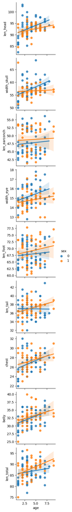

```python
### Code - Pairplot

sns.pairplot(possum_data, x_vars=x_vars,  y_vars=y_vars, hue='sex', kind='reg')
plt.show()
```

Then we draw heatmaps for both male and female to see the difference of sex variables in terms of correlation.

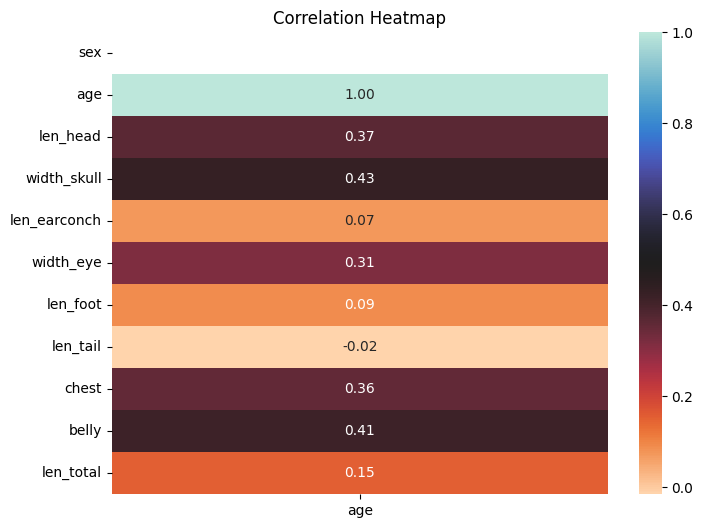

```python
# Heatmaps to visualize correlations between each sex with variables other than age for age variable

correlation_matrix_male = possum_data[possum_data['sex']==0].corr()
plt.figure(figsize=(8, 6))
sns.heatmap(correlation_matrix_male[['age']], annot=True,  fmt='.2f', cmap='icefire_r')
plt.title('Correlation Heatmap')
plt.show()
```

For the male sex, it is seen that, apart from age itself, age has the most correlation with width_skull(0.43), which is a possitve correlation, and the least with len_tail(-0.02) which is a negative correlation. Close values are also belly-age correlation which is 0.41, and age-len_head correlation which is 0.37 and age-width_eye correlation which is 0.31. Small values are also age-len_total which is 0.15 and age-len_foot which is 0.09 and so on. In this way, heatmaps can be used to measure relationships.

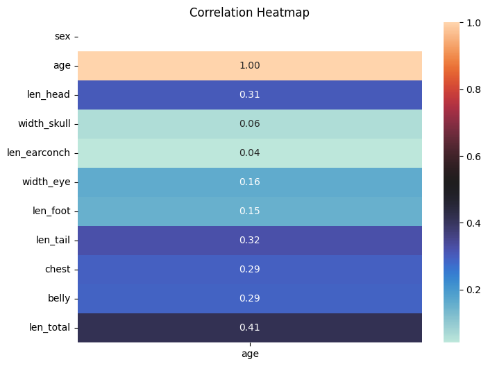

```python
correlation_matrix_female = possum_data[possum_data['sex']==1].corr()

# Heatmap to visualize correlations
plt.figure(figsize=(8, 6))
sns.heatmap(correlation_matrix_female[['age']], annot=True,  fmt='.2f', cmap='icefire')
plt.title('Correlation Heatmap')
plt.show()
```

In the case of females, apart from age itself, age has max correlation with len_total(0.41), then len_tail(0.32), and then both chest and belly with 0.29 correlations respectively. It has very minimal correlation with width_skull(0.06) and len_earconch as 0.04. And has almost similar values close to 0.15 for both width_eye and len_foot.

Hence, it is seen that, there are clear differences between male and female sexes with different variables in terms of the age variable.

Before the regression analysis itself, let's check that our dataset is in a proper format. We'll also perform the train-test split as we're going to first tune the hyperparameters for each model using the training set and test the overall performance of the chosen models using the test set.

**Exercise 5 B)**

Do you need to prepare the data a little? Explain your decision. Perform the train-test (80/20) split.

```python
#Standard Scaling for possum features
scaler = StandardScaler()
possum_features=pd.DataFrame(scaler.fit_transform(possum_features),columns=possum_features.columns)
```

```python
### Code - Data preparation
possum_X_train, possum_X_test, possum_y_train, possum_y_test = train_test_split(possum_features, possum_labels, test_size=0.20, random_state=42)
possum_X_train.head(2)
```

|  | sex | len_head | width_skull | len_earconch | width_eye | len_foot | len_tail | chest | belly | len_total |
| --- | --- | --- | --- | --- | --- | --- | --- | --- | --- | --- |
| 89 | -0.843721 | -1.008409 | -0.958901 | -0.800372 | -2.136433 | -1.047004 | 0.484478 | -1.524030 | -0.603717 | -1.261815 |
| 26 | 1.185227 | -0.637113 | -0.796946 | 0.659951 | -0.807389 | 0.433095 | -1.044655 | -2.021371 | -1.709012 | -0.543420 |

\

### **Preparation of Data:**

**Scaling:** Both KNN and Ridge Regression require scaling. In order to guarantee optimal model performance, data preparation is essential prior to model training. The features must be scaled or normalized for many machine learning algorithms, such as k-NN, especially if the features have different units or are on different scales. This makes sure that no feature, no matter how big, dominates the model training.

**Splitting into train and test:** To assess the models' performance on data that hasn't been seen yet, it's also critical to divide the data into test and training sets.

Overfitting is a danger associated with training and testing the full dataset as the model may pick up on certain data patterns and perform well on known data but badly on fresh, unknown data. This method reduces the model's capacity to generalize to actual situations. Assessing using the same set of data that were used for training may result in biased conclusions, which might inflate performance metrics and falsely suggest the efficacy of the model. By dividing the dataset into training and test sets, it is possible to fairly assess the model's capacity for generalization and provide a more accurate estimate of its performance on untested data—an evaluation that is essential for determining the model's practicality.

Regarding the k-NN, we have already get familiar with the optimization of the k value. The idea behind the k-NN is the same as previously in classification, the output isn't a class anymore but a continuous value. So, for now, we can stick to the optimal k value. However, for Ridge Regression, we'll focus on the hyperparameter called $\lambda$ (read as 'lambda'), the regularization term (or penalty term or L2 penalty, how ever we'd like to call it), and try to find its optimal value for this task. After the model selection for both regression is performed, we compare the chosen models using a metric called mean absolute error (MAE).

**Exercise 5 C)**

Train multiple ridge regression models and k-NN regression models. For hyperparameters, use $\lambda=2^{-10}...2^{10}$ and $k=1...30$. Once again, use leave-one-out cross validation. Remember to use only the training dataset for model selection. Plot the optimal k values and lambdas versus corresponding MAEs (two different plots).

- Introduce the optimal hyperparameters for each regression model.
- How do you interpret the MAE in our case when the target variable is age?

*Note: In a `sklearn.linear_model.Ridge` class, lambda is called as "alpha" so don't get confused.*

```python
### Code - CV for Ridge regression and k-NN regression
```

```python
#Ridge Regression
import math
mae_ridge_cross=[]
alpha_ridge_cross = [2**exp for exp in list(range(-10, 11)) ]

grid_ridge = GridSearchCV(Ridge(), {'alpha': alpha_ridge_cross}, cv=LeaveOneOut(), scoring='neg_mean_absolute_error')
grid_srch_cv_ridge = grid_ridge.fit(possum_X_train, possum_y_train)

"""
for a in alpha_ridge_cross:
    Ridge_clf = Ridge(alpha=a)
    Ridge_clf.fit(possum_features, possum_labels)
    loo_scores_ridge = cross_val_score(Ridge_clf, possum_features, possum_labels, cv=LeaveOneOut(), scoring='neg_mean_absolute_error')
    mae_ridge_loocv = np.mean(loo_scores_ridge)
    mae_ridge_cross.append(abs(mae_ridge_loocv))


alpha_ridge_cross=pd.DataFrame(alpha_ridge_cross, columns=["Alpha"])
mae_ridge_cross=pd.DataFrame(mae_ridge_cross, columns=["MAE"])
len(alpha_ridge_cross)
#alpha_ridge_cross
mae_ridge_df=pd.concat([alpha_ridge_cross, mae_ridge_cross], axis="columns")
mae_ridge_df.head()
"""
```

[output not shown]

```python
ridge_cv_res = pd.DataFrame(grid_srch_cv_ridge.cv_results_)
ridge_cv_res["MAE"]=ridge_cv_res["mean_test_score"].abs()
print("Best Parameters by Grid Search CV for Ridge Regression are :", grid_srch_cv_ridge.best_params_)
```

```
Best Parameters by Grid Search CV for Ridge Regression are : {'alpha': 64}
```

```python
ridge_cv_res[["param_alpha","mean_test_score", "MAE"]].head(3)
```

|  | param_alpha | mean_test_score | MAE |
| --- | --- | --- | --- |
| 0 | 0.000977 | -1.539401 | 1.539401 |
| 1 | 0.001953 | -1.539391 | 1.539391 |
| 2 | 0.003906 | -1.539372 | 1.539372 |

```python
#KNN
grid_knn = GridSearchCV(KNeighborsRegressor(), {'n_neighbors': list(range(1,31))}, cv=LeaveOneOut(), scoring='neg_mean_absolute_error')
grid_srch_cv_knn = grid_knn.fit(possum_X_train, possum_y_train)

grid_srch_cv_knn.best_params_["n_neighbors"]
```

```
4
```

```python
knn_res_cv = pd.DataFrame(grid_srch_cv_knn.cv_results_)
knn_res_cv["MAE"]=knn_res_cv["mean_test_score"].abs()
print("Best Parameters by Grid Search CV for KNN Regression are :", grid_srch_cv_knn.best_params_)
```

```
Best Parameters by Grid Search CV for KNN Regression are : {'n_neighbors': 4}
```

```python
knn_res_cv[["param_n_neighbors","mean_test_score", "MAE"]].head(3)
```

|  | param_n_neighbors | mean_test_score | MAE |
| --- | --- | --- | --- |
| 0 | 1 | -1.71250 | 1.71250 |
| 1 | 2 | -1.46875 | 1.46875 |
| 2 | 3 | -1.38750 | 1.38750 |

```python
#knn_reg = KNeighborsRegressor(n_neighbors=grid_srch_cv_knn.best_params_["n_neighbors"])
#knn_reg.fit(possum_X_train, possum_y_train)
#knn_reg_acc=knn_reg.score(knn_reg.predict(possum_X_test), possum_y_test)
```

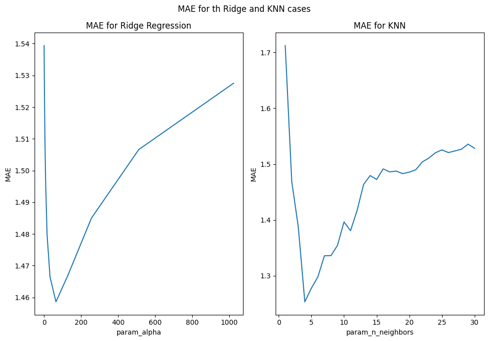

```python
fig, axes = plt.subplots(ncols=2, figsize=(10,7))
sns.lineplot(data=ridge_cv_res,x='param_alpha', y='MAE', ax=axes[0]).set(title='MAE for Ridge Regression')
sns.lineplot(data=knn_res_cv,x='param_n_neighbors', y='MAE', ax=axes[1]).set(title='MAE for KNN')
fig.suptitle("MAE for th Ridge and KNN cases")
plt.tight_layout()
plt.show()
```

\

The Mean Absolute Error (MAE) for age prediction indicates how much, on average, the model's predicted ages deviate from the actual ages. A lower MAE signifies more accurate predictions, where the model's estimated ages closely align with the true ages. Conversely, a higher MAE implies less precision, indicating greater discrepancies between predicted and actual ages. Ultimately, the MAE serves as a measure of the model's performance in estimating ages, with smaller values indicating higher accuracy in age prediction.

The cross-validation was employed for model selection and at this point, we have the optimal hyperparameter settings for each model. Let's finally assess both models using the test set. To continue from this, we first fit the chosen models using the entire training, ensuring that the models are trained with the maximum available data.

**Exercise 5 D)**

Fit the chosen models with the whole training set. Evaluate the models using the test set and describe the results.

- How well did the models perform in estimating the possums' ages?
- So, what's the pitfall in here if you had compared the overall performance of the models based on the cross-validation MAEs and not the MAEs for the test set?

```python
## Code - Evaluating the selected models


# Initialize Ridge Regression and k-NN Regression models
ridge_model = Ridge(alpha= grid_srch_cv_ridge.best_params_["alpha"])
knn_model = KNeighborsRegressor(n_neighbors=grid_srch_cv_knn.best_params_["n_neighbors"])

# Fit models with the whole training set
ridge_model.fit(possum_X_train, possum_y_train)
knn_model.fit(possum_X_train, possum_y_train)
```

```
KNeighborsRegressor(n_neighbors=4)
```

```python
# Predict using test set
ridge_preds = ridge_model.predict(possum_X_test)
knn_preds = knn_model.predict(possum_X_test)

# Calculate Mean Absolute Error (MAE) for test set predictions
ridge_mae = mean_absolute_error(possum_y_test, ridge_preds)
knn_mae = mean_absolute_error(possum_y_test, knn_preds)
```

```python
print(f"Ridge Regression Test MAE: {ridge_mae}")
print(f"k-NN Regression Test MAE: {knn_mae}")

# Cross-validation MAE comparison
ridge_cv_scores = cross_val_score(ridge_model, possum_X_train, possum_y_train, scoring='neg_mean_absolute_error', cv=LeaveOneOut())
knn_cv_scores = cross_val_score(knn_model, possum_X_train, possum_y_train, scoring='neg_mean_absolute_error', cv=LeaveOneOut())

print(f"Ridge Regression CV MAE: {-ridge_cv_scores.mean()}")
print(f"k-NN Regression CV MAE: {-knn_cv_scores.mean()}")
```

```
Ridge Regression Test MAE: 1.5083235130374324
k-NN Regression Test MAE: 1.5595238095238095
Ridge Regression CV MAE: 1.4586083423970824
k-NN Regression CV MAE: 1.253125
```

\

The evaluation metrics here are the MAEs for both the Ridge Regression and k-NN Regression models. Lower MAE values indicate better performance in estimating possum ages. Comparing the MAEs obtained from the test set provides insight into how well these models generalize to unseen data.

Our results(MAE) for Ridge Regression using Test Set indicate that our results are 1.5 years offset from the main value. Similarly, results(MAE) for KNN Regression using Test Set are 1.6 offset from the main value. And Ridge Regression MAE indicates that the cross validation scores are 1.45 years offset from the main value and KNN Regression MAE on the cross validation sets indicate 1.25 years ofset from the main value.

**Pitfall of Relying Solely on Cross-Validation MAEs:** The pitfall lies in the fact that cross-validation scores might not accurately represent the model's performance on entirely new, unseen data. If the model selection is based only on cross-validation scores, it might lead to choosing a model that performs well on the specific subsets used during cross-validation but does not generalize well to the test set. This issue arises due to overfitting to the specifics of the cross-validation sets and may not reflect the model's true performance on new, independent data.

In our case, The Cross Validation Errors are much less than test set results. While cross-validation is valuable for model selection and hyperparameter tuning, solely relying on it for model comparison without validating on an independent test set can lead to a misleading assessment of a model's generalization capabilities. The test set provides a more reliable estimate of how well the models perform on unseen data and is essential for final model evaluation and selection.

## BONUS: Feature selection - most useful features in predicting cardiovascular diseases

You can stop here and get the "pass" grade! To get the "pass with honors" grade, you need to do the following exercise. This means you'll get one bonus point for the exam.

The exercise is not as straightforward as the previous ones, and may require you to do some research of your own. You are also required to **explain** the steps you choose with your own words, and show that you tried to understand the idea behind the task. There's no single correct solution for this so just explain what you did and WHY you did it.

Unfortunately, due to the lack of resources and time, doctors can't measure all the values represented in the given cardio dataset. Fortunately, eager students are willing to help: Your task is to identify four [4] most useful features for predicting the presence of the CVD from the dataset. The steps needed for this job are presented above except the feature selection part. You must remember not to leak any information from the test set when selecting the features, i.e., you try to find those five features using only the training set.

Regarding the feature selection itself, you may choose your weapon from the three categories: filter methods, embedded methods or wrapper methods. Use two methods from two different category and compare their outputs. Bonus material about the methods is provided in Moodle.

Evaluate the model of your choice with the limited dataset by examining the confusion matrix and computing the accuracy and the AUROC.

**Discuss** your findings and results.

\

Embedded techniques: machine learning approaches with feature selection mechanisms integrated such as Random forests, Lasso, and Decision trees. For our experiment, we used Random Forerst Classifier as the Embedded technique. We took 100 estimators and fit them on the training data. We also kept the feature importance in a DataFrame variable called feature_importance_df using the feature importances found by fitting by random forest classifier. Using that, we find out the selected 4 features.

```python
#Embedded
from sklearn.ensemble import RandomForestClassifier

# Initializing the Random Forest classifier with 100 estimators and random state
rf = RandomForestClassifier(n_estimators=100, random_state=42)

# Fitting the Random Forest classifier on training data
rf.fit(cardio_X_train, cardio_y_train)

# Extracting the importances of feature
feature_importances = rf.feature_importances_

# Creation of a DataFrame to assign feature names to their corresponding importances
feature_importance_df = pd.DataFrame({'Feature': cardio_X_train.columns, 'Importance': feature_importances})

# Sorting all the features in terms of their importance and extract top 4
importance_descending=feature_importance_df.sort_values(by='Importance', ascending=False)
selected_features_rf_4 = importance_descending.head(4)['Feature']
selected_features_rf_4=selected_features_rf_4.tolist()
print("Selected Features are: ",selected_features_rf_4)
```

```
Selected Features are:  ['weight', 'ap_hi', 'age', 'height']
```

Then we used LogisticRegression model according to our choice and used only our 4 selected features extracted by the embedded technique we used above.

```python
from sklearn.linear_model import LogisticRegression
from sklearn.metrics import roc_auc_score

# Creating a logistic regression model
model = LogisticRegression()

# Training the model using the selected features
model.fit(cardio_X_train[selected_features_rf_4], cardio_y_train)

# Making predictions on the test set
cardio_X_train_selected=cardio_X_train[selected_features_rf_4]
cardio_X_test_selected=cardio_X_test[selected_features_rf_4]

y_pred_rf = model.predict(cardio_X_test_selected)

# Calculating evaluation metrics
accuracy = accuracy_score(cardio_y_test, y_pred_rf)
print("Accuracy:", accuracy)
```

```
Accuracy: 0.7333333333333333
```

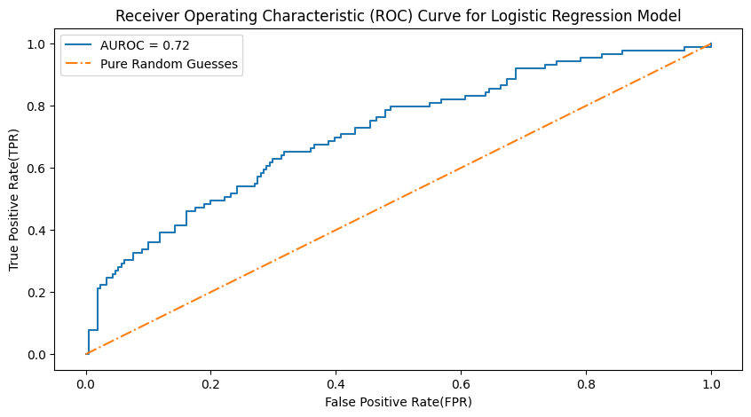

```python
# Plotting the ROC curve

# Predict probabilities for the test set
probs = model.predict_proba(cardio_X_test_selected)
preds = probs[:, 1]  # considering only the positive class probabilities

# Calculate ROC curve
fpr, tpr, threshold = roc_curve(cardio_y_test, preds)

# Calculate AUC score
auroc = roc_auc_score(cardio_y_test, preds)

plt.figure(figsize=(10, 5))
plt.plot(fpr, tpr, label  =  f'AUROC = {auroc:.2f}')
plt.plot([0, 1], [0, 1], linestyle='-.', label='Pure Random Guesses')
plt.xlabel('False Positive Rate(FPR)')
plt.ylabel('True Positive Rate(TPR)')
plt.title('Receiver Operating Characteristic (ROC) Curve for Logistic Regression Model')
plt.legend()
plt.show()
```

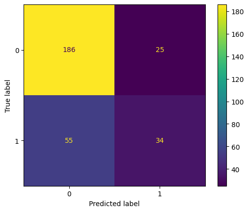

```python
cm = confusion_matrix(cardio_y_test, y_pred_rf)

disp = ConfusionMatrixDisplay(confusion_matrix=cm,
                              #display_labels=results_clf.classes_
                             )
disp.plot()
plt.show()
```

Wrapper techniques: the search algorithm assigns a score to feature sets based on the predictability of the classifier/regressor method trained on them. **Examples:** Genetic algorithms, floating search, retrograde elimination, and forward search.

**Benefits include:** compatibility with any classifier or regression technique, ability to identify features most appropriate for a specific method, avoidance of duplicate features, and potential for smaller feature sets than embedded approaches.

**Cons:** intricate search techniques that are computationally demanding and prone to overfitting

We used floating search as the wrapper technique. Floating search is a feature selection method that combines forward and backward selection. It starts with an initial set of features, then iteratively adds and removes features based on performance improvement. Here's an example of how you can perform floating search.

For this purpose, we use SequentialFeatureSelector. This takes in a random forest model and takes in the parameters forward, fleeting, and the number of features to choose from. Upon fitting on our data, we can then use the model to get the selected feature indices from which we can get the chosen features.

```python
from mlxtend.feature_selection import SequentialFeatureSelector as SFS
from sklearn.ensemble import RandomForestClassifier

# Initializing a Random Forest classifier
rf = RandomForestClassifier(n_estimators=100, random_state=42)

# Creating a Sequential Forward Floating Selection (SFFS) object
sffs = SFS(rf,# Random Forest model passed
            k_features=(1, 4),  # Extract between 1 to 4 features
            forward=True,  # Enabling Forward selection
            floating=True,  # Enabling Floating selection
            scoring='accuracy') #Scoring using accuracy

# Fitting SFFS on training data
sffs = sffs.fit(cardio_X_train, cardio_y_train)

# Saving selected feature indices
selected_feature_indices = sffs.k_feature_idx_

# Saving selected feature  in list
selected_features_floating = list(cardio_X_train.columns[list(selected_feature_indices)])
print("Features Selected by Floating Search: ",selected_features_floating)
```

```
Features Selected by Floating Search:  ['ap_hi', 'alco', 'cholesterol_high', 'gluc_high']
```

```python
from sklearn.linear_model import LogisticRegression
from sklearn.metrics import roc_auc_score

cardio_X_train_selected2=cardio_X_train[selected_features_floating]
cardio_X_test_selected2=cardio_X_test[selected_features_floating]

# Creating a logistic regression model
model = LogisticRegression()

# Training the model using the selected features from Embedded technique
model.fit(cardio_X_train_selected2, cardio_y_train)

# Making predictions on the test set
y_pred_forward = model.predict(cardio_X_test_selected2)

# Calculate evaluation metrics
accuracy = accuracy_score(cardio_y_test, y_pred_forward)
print("Accuracy:", accuracy)
```

```
Accuracy: 0.76
```

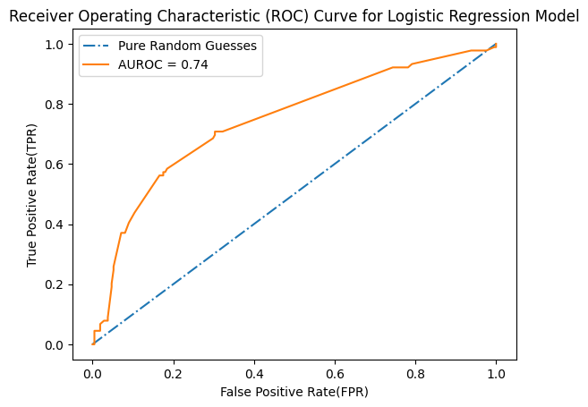

```python
### Code - ROC curve and AUROC

probs = model.predict_proba(cardio_X_test_selected2)
preds = probs[:, 1]  # considering only the positive class probabilities

# Calculate ROC curve
fpr, tpr, threshold = roc_curve(cardio_y_test, preds)

# Calculate AUC score
auroc = roc_auc_score(cardio_y_test, preds)

plt.plot([0, 1], [0, 1], linestyle='-.', label='Pure Random Guesses')
plt.plot(fpr, tpr, label=f'AUROC = {auroc:.2f}')

plt.ylabel('True Positive Rate(TPR)')
plt.xlabel('False Positive Rate(FPR)')

plt.title('Receiver Operating Characteristic (ROC) Curve for Logistic Regression Model')
plt.legend()
plt.show()
```

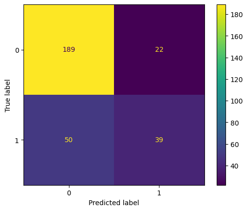

```python
cm = confusion_matrix(cardio_y_test, y_pred_forward)

disp = ConfusionMatrixDisplay(confusion_matrix=cm,
                             )
disp.plot()
plt.show()
```

For the first case, that is our embedded technique(Random Forest), the accuracy was 0.73 and Area under the curve was 0.72. And from the confusion matrix,

True Postive= 34

True Negative= 186

False Positive= 25

False Negative= 55

True Postive= 39

True Negative= 189

False Positive= 22

False Negative= 50